# Qu’est-ce que le Tiers? Tout.

De l’Assemblée à la Nation

Auteur·rice

Skarbimir Prokopek

**La Révolution n’est pas finie**. Cette phrase, empruntée à **Georges Clemenceau**, sonne comme une conclusion – et ce sera notre conclusion. Mais il faut aussi partir de là: l’histoire de la Révolution française ne s’est jamais «refroidie», comme le voudraient ses historiens les plus conservateurs (F. Furet). Elle continue à susciter des émotions, elle est la référence de tous les moments de trouble et de lutte (rappelez-vous des Gilets Jaunes!), elle reste le repoussoir de ses ennemis. Malgré les 230 ans qui nous séparent de la Révolution française, il n’y a pas une seule idée ou proposition discutée aujourd’hui dans nos instances politiques que l’on ne puisse pas retracer jusqu’à la Révolution, et toutes les positions politiques actuellement présentes sur la scène politique (nous sommes bien une année électorale, n’oubliez pas) se laissent définir par un certain rapport à la Révolution.  
Nous discutons encore les idées posées lors de la révolution, nous menons encore les batailles engagées alors. Un jour, ces idées et ces batailles ne signifieront plus grand-chose, sauf pour les historiens. Nous aurons alors changé d’ère; ce que nous nommons encore la *période contemporaine*, une fois clôturée, recevra alors un nom différent. Mais nous n’en sommes pas là pour le moment: c’est bien pour cela que ces gens en habits exubérants, nés dans un monde qui ne ressemble plus du tout au nôtre, sont *quand même* nos **contemporains**.

Depuis son déclenchement, la Révolution a été l’objet des travaux des historiens et des interprétations politiques. Sans retracer ici toute l’évolution des idées dominantes sur cette période, il faut avoir en tête l’influence encore présente de la période du **bicentenaire** de la Révolution, commémoré en 1989. Dans le contexte de l’époque, marqué par l’affaiblissement de l’URSS et par l’affirmation d’une «liberté à l’anglaise», hostile aux changements brusques, s’impose une présentation de la Révolution assez méfiante, plutôt conservatrice politiquement. L’on reconnaît 1789, où l’on voit une réalisation sage des idées des Lumières, mais on rejette 1793, comme un excès violent: cette Révolution-là paraît décidément trop révolutionnaire. Si ce récit est encore largement présent, il est largement remis en cause aujourd’hui.

La nécessité de se confronter à l’histoire de la Révolution tient d’abord à sa place de la matrice, ou acte de naissance, de la France contemporaine qui détermine encore nos débats.  
Deuxièmement, il faut observer ce qu’est une *séquence révolutionnaire*: comment un système social s’effondre et bascule dans un autre, qu’est-ce qui en reste; quel est, enfin, le rôle des acteurs qui peuvent accepter, accompagner la Révolution, se sacrifier pour elle ou bien la combattre, mais jamais la *faire*.

Mentionnons enfin la difficulté technique inséparable de ce sujet: la Révolution française est un sujet gigantesque devant lequel il est impossible de n’être pas intimidé. Peu de périodes (la Seconde guerre mondiale, peut-être?) atteignent ce degré invraisemblable de densité où des événements majeurs se précipitent à tel point que la chronologie avance jour par jour, voire heure par heure. Ce n’est pas un hasard si les historiens de l’Époque moderne s’arrêtent en général à l’année 1789, ceux de l’époque contemporaine démarrent souvent en 1815. La Révolution, dans une moindre mesure l’Empire, sont dans la pratique des études une période à part, avec ses spécialistes et ses débats.  
Il nous faudra donc survoler et synthétiser à toute vitesse, avec une multitude de regrets.

## 1 Que veut le Tiers état? À être quelque chose

La Révolution n’arrive pas dans le vide: au contraire, on la voit venir depuis quelques années, comme une fatalité. Pour autant, personne ne peut, avant la Révolution, savoir exactement ce que la Révolution sera.

### 1.1 Qu’est-ce que le Tiers état a été? Rien

Qu’est-ce que la France monarchique d’avant la Révolution a été? Il faudrait ici repartir dans le programme des années passées, mais rappelons les caractéristiques qui vont nous intéresser ici.

C’est une *monarchie*, bien entendu. Elle est dirigée par un roi, dont le pouvoir s’est affirmé au cours d’une très longue lutte contre le pouvoir de la grande noblesse. Le roi n’est pas seul: s’il n’y a plus les grands ministres du xvii<sup>e</sup> siècle, à l’image de Richelieu ou de Mazarin, il y a bien un appareil d’État, dans lequel les ministres réformateurs, comme Turgot ou Necker, issus de la bourgeoisie, jouent un grand rôle.

Cette monarchie est *absolue*. Cela signifie que le roi est lui-même la source du pouvoir, qu’il ne le tient de personne d’autre, sinon de Dieu; cela signifie aussi, bien sûr, qu’il ne peut y avoir aucune séparation des pouvoirs. C’est que qu’exprime la formule *Car tel est notre bon plaisir* qui conclut les actes royaux. Cependant, cela ne signifie en aucun cas que le roi fait ce qu’il veut. En pratique, son pouvoir est limité par un enchevêtrement des droits et privilèges accumulés au cours des siècles et qu’il n’est pas possible d’écarter sans mettre en danger tout l’édifice social.

Elle est *de droit divin*: le pouvoir vient, en principe, de Dieu; le roi serait lieutenant (c’est-à-dire littéralement tenant-lieu-de). Sa voix est la voix de Dieu, lui désobéir est désobéir à Dieu.

[figure not shown]

Caricature contemporaine des trois ordres

L’**Ancien régime** est une **société d’ordres**, c’est-à-dire qu’elle est ordonnée selon une hiérarchie de *dignité* et d’*honneur*. La richesse suit mais en principe (de moins en moins vrai), elle est secondaire. La question essentielle est celle du **privilège** de naissance. La vraie distinction passe ainsi entre les deux ordres privilégiés et le Tiers, qui est un fourre-tout défini de manière négative. La séparation entre l’état de la noblesse et celui du clergé est secondaire: l’Église offre un choix de carrière très intéressant pour des nobles. La **hiérarchie ecclésiastique** (évêques, archevêques, cardinaux, abbés de certaines grands établissements religieux) sont tous des grands nobles, contrairement au bas clergé (les prêtres des campagnes, curés des paroisses, moines), qui fait partie du Tiers.

> Que si les aristocrates entreprennent, au prix même de cette liberté, dont ils se montreraient indignes, de retenir le peuple dans l’oppression, il osera demander à quel titre. Si l’on répond à titre de conquête, il faut en convenir, ce sera vouloir remonter un peu haut. Mais le Tiers ne doit pas craindre de remonter dans des temps passés. Il se reportera à l’année qui a précédé la conquête; et puisqu’il est aujourd’hui assez fort pour ne pas se lausser conquérir, sa résistance sans doute sera plus efficace. Pourquoi ne renverrait-il pas dans les forêts de la Franconie toutes ces familles, qui conservant la folle prétention d’être issues de la race des conquérants et d’avoir succédé à leurs droits?  
> La Nation, alors épurée, pourra se consoler, je pense, d’être réduite à ne se plus croire composée que des descendants des Gaulois et des Romains.

> Emmanuel-Joseph Sieyès, *Qu’est-ce que le Tiers état?*, 1789. Sieyès répond ici aux idées du marquis de Boulainvilliers qui faisait descendre la noblesse des Francs et les roturiers des Gaulois, transformant ainsi la hiérarchie sociale en une hiérarchie des races.

Ce découpage de la société, de moins en moins accepté, est certes hérité du vieux découpage médiéval en ordre de ceux qui prient (*Oratores*, le clergé), ceux qui combattent (*Bellatores*, ce qui correspond à l’aristocratie laïque qui se voit descendante des chevaliers, voire des conquérants francs et se définit en fin de compte comme une caste guerrière) et ceux qui travaillent (*Laboratores*, les producteurs, réunissant les paysans et les artisans); mais ce découpage-là assignait des fonctions dans la société, ce l’on ne trouve pas à la fin du xviii<sup>e</sup> siècle.

### 1.2 Une longue crise de la monarchie

À la fin du xviii<sup>e</sup> siècle, la France est enlisée dans une longue crise dont on ne voit plus l’issue autrement que dans des changements importants.L’époque de Louis XIV est loin; le siècle qui s’est écoulé depuis sa mort a été marqué par des défaites militaires, dont la catastrophique Guerre de Sept ans, qui aurait mérité le nom de Première guerre mondiale, et qui voit la France perdre l’essentiel de son empire colonial face à une Angleterre qui agit et pense en puissance globale. La guerre d’indépendance américaine, malgré la défaite anglaise, est un désastre économique pour la France qui supporte une bonne partie du coût de cette guerre sans obtenir les avantages économiques qu’elle espérait.

Si les guerres coûtent cher, l’État monarchique n’est pas équipé pour y répondre. L’administration est inefficace et peine à ne serait-ce savoir quelle est au juste la situation. Mais dans tous les cas, elle est mauvaise: à la veille de la Révolution, le déficit de l’État est de 20%, 136 millions de livres d’emprunts sont prévus. La dette a triplé en 15 ans de règne de Louis XVI, elle s’élève déjà à 5 milliards de livres et son service, de 318 millions de livres, absorbe 50% des dépenses.

Le système fiscal est au cœur du blocage: il est inefficace, injuste, et exerce une pression élevée sans pour autant répondre aux besoins. Son élément principal est la **taille**. Elle pèse uniquement sur les **roturiers** (non-nobles) et est repartie territorialement: le roi indique dans un *brevet de taille* combien il souhaite percevoir dans telle province; on répartit ensuite cette charge dans les généralités, puis les paroisses. Ainsi, la charge fiscale varie d’une province à l’autre.

La **capitation** est un impôt personnel qui devait peser sur tout le monde, mais en pratique, elle pèse elle aussi uniquement sur les roturiers, tout comme le **vingtième**. Les impôts **indirects**, qui pèsent sur certaines marchandises, comme la **gabelle du sel**, ainsi que les péages routiers, varient d’une province à l’autre; surtout, ces impôts sont confiés à des financiers privés, des *fermiers généraux* qui avancent l’argent au roi puis se remboursent en prélevant les impôts; ce système favorise la corruption et les abus, et les fermiers généraux font objet d’une profonde haine populaire.

Les impôts pèsent sur les roturier (non-nobles): l’Église a racheté les impôts, les nobles refusent de les payer. C’est le cœur du blocage: les finances du pays ne peuvent pas être réparées sans faire payer la noblesse.

Des tentatives ont pourtant été faites. Le contrôleur général des finances **Turgot** entreprend des réformes mais le fait en se refusant la banqueroute, l’augmentation des impôts et l’emprunt. Il ne peut donc que tenter de réduire les dépenses, ce qui ne suffit pas. Inspiré par les principes des **physiocrates**, il libéralise le commerce de blé et le travail industriel. Or, cette tentative se solde par un échec: les prix de blé s’envolent, l’État refuse d’intervenir et faire circuler le blé pour soulager les disettes. Les paysans accusent les seigneurs locaux de spéculation (pas toujours à tort), le prestige royal souffre, puisque le roi n’est plus la figure paternelle et protectrice. Après l’écrasement des révoltes (la **Guerre des farines** de 1775), le roi renvoie Turgot et annule les réformes.

[figure not shown]

*Le Fermier brûlé ou la famille pauvre*, gravure contemporaine de François-Philippe Charpentier (1734-1817)

### 1.3 Lumières et révolutions: un nouveau cadre mental

L’Ancien régime est miné par un long travail de sape des évolutions culturelles. Les **Lumières**, au sens strict du terme, sont la manifestation la plus visible, mais pas la cause, de ces changements. En 1786, 47% des hommes et 27% de femmes savent lire; les livres circulent et échappent à la censure.  
Les écrivains et penseurs des philosophes des Lumières critiquent l’arbitraire du pouvoir absolu, dont le symbole est la Bastille (ou l’on emprisonne - ou *embastille* souvent pour des délits liés aux écrits; voire sur une **lettre de cachet**) sans pour autant réclamer la fin de la monarchie. Le privilège de naissance est vu comme injuste et attaqué.  
La cible principale de la critique des Lumières est l’Église catholique (cf l’affaire Calas qui fait la célébrité de Voltaire) dont on dénonce l’**obscurantisme**. De fait, l’emprise de la religion s’affaiblit: à la veille de la Révolution, 30% des enfants naissent à Paris hors mariage. La déchristianisation de la société atteint nécessairement l’image sacrée du roi, qu’on continue pourtant à voir comme bon et bienveillant.

> Parce que vous êtes un grand seigneur, vous vous croyez grand génie!

> Noblesse, fortune, un rang, des places: tout cela rend si fier! Qu’avez-vous fait, pour tant de biens? Vous vous êtes donné la peine de naître, et rien de plus, du reste, homme assez ordinaire!  
> Tandis que moi, morbleu! perdu dans la foule obscure, il m’a fallu déployer plus de science et de calculs pour subsister seulement, qu’on n’en a mis depuis cent ans à gouverner toutes les Espagnes!

> Pierre-Augustin Caron de Beaumarchais, *Le Mariage de Figaro*, V. 3, 1778

La France de l’Ancien régime finissant n’est pas non plus isolée des inspirations étrangères. Or, le monde est entré dans une **ère des révolutions** qui interagissent et s’inspirent mutuellement.  
La *Glorieuse révolution* britanique (1688) avait transformé la monarchie britannique en une monarchie parlementaire où un *Bill of rights* (1689) limite les pouvoirs du roi et garantit des libertés individuelles. Le système britannique est assez généralement admiré en France; on le perçoit comme un modèle à suivre et un potentiel avenir.

Plus près dans le temps, la révolution américaine a un écho important. La France a largement contribué à la victoire américaine, sans pouvoir recueillir des fruits économiques ni même diplomatiques de son effort, mais un certain nombre d’acteurs français, dont le plus célèbre est La Fayette, ont fait l’expérience de cette révolution. Le cas américain met en cause une certitude de l’époque: on pense alors que la république, système politique de la Rome antique et de quelques cités maritimes d’Italie, qui sont alors dans un déclin avancé, n’est bonne que pour de petits États. Les États-Unis sont ainsi la première république moderne et première république au territoire vaste. Le rôle de **Benjamin Franklin**, déjà célèbre en tant que savant, est important. Premier ambassadeur états-unien à Paris, il est pendant plusieurs années au cœur de la sociabilité politique et littéraire de Paris.

[figure not shown]

Benjamin Franklin reçu par Louis XVI en mars 1778. Gravure allemande de 1784

## 2 L’Été 1789: la Nation en actes

La convocation des États généraux apparaît comme inévitable. Le roi s’y résout enfin malgré l’hostilité des nobles. Le risque politique est bien présent: le sentiment que l’ordre politique de la France ne survivra pas à cette délibération est assez répandu.

> **17 octobre 1787** : j’ai dîné aujourd’hui avec un groupe de personnes dont la conversation fut entièrement politique (…). Une opinion prévalait, c’est qu’on était à l’aurore d’une grande révolution (…) ; que tout le montre : la grande confusion dans les finances, avec un déficit impossible à combler sans les états généraux du royaume (…). Sur le trône, un prince animé d’excellentes intentions mais n’ayant pas les ressources d’intelligence suffisantes pour gouverner en un tel moment ; une cour ensevelie dans le plaisir et la dissipation (…). Une grande agitation dans tous les rangs de la société désireuse de changement sans savoir que chercher ; un grand besoin de liberté croissant depuis la Révolution américaine ; le tout forme une combinaison de circonstances qui annonce une grande fermentation et agitation (…). Tous s’accordent à dire que les états généraux du royaume ne peuvent s’assembler sans qu’une plus grande liberté n’en soit la conséquence.

> Arthur Young, Voyages en France, 1787, 1788, 1789, 1794

Arthur Young est un observateur précieux, qui a voyagé à travers la France à la veille de la Révolution. Il nous a laissé un véritable tableau de la situation, qu’il publie alors que la Révolution est en cours, et elle déplaît à son tempérament conservateur. Agronome écossais, il est habitué au système politique britannique, qu’il considère naturellement comme supérieur et comme un modèle pour la France: mais en cela, il s’accorde avec beaucoup de Français qui depuis le milieu du siècle envient les institutions anglaises.

Les États généraux sont enfin convoqués en **août 1788**, pour l’été de l’année suivante. C’est une institution antique, qui a plus de 400 ans d’existence (il sont été convoqués pour la première fois en 1302, par Philippe IV le Bel), mais ils ne sont réunis que rarement, dans les circonstances exceptionnelles. Les États généraux n’avaient pas été réunis depuis 1614. C’est le plus large des conseils qui assistent le roi mais en soi, n’a pas d’autorité législative.

### 2.1 Le Jeu de Paume: la révolution des représentants

Le processus de changements profonds commence dès l’annonce de leur réunion. Il faut une préparation complexe. Le conflit clé émerge tout de suite: la noblesse souhaite garder les anciennes formes de 1614, le nombre égal de députés pour chaque ordre et le vote par état, ce qui garantit automatiquement la majorité aux privilégiés. Les réformateurs souhaitent doubler le nombre des députés du Tiers et passer au vote par tête (donc, un député aurait une voix), ce qui donnerait une majorité au Tiers. Le roi se méfie des nobles et accepte le doublement du Tiers, en laissant la question du vote aux États généraux eux mêmes.

La période entre la convocation et la réunion des états généraux donne lieu à une effervescence de réflexion politiques, menées dans tous les lieux de sociabilité existants: cafés, salons, sociétés savantes, cabinets de lecture etc. En une année, 2500 pamphlets (courtes brochures politiques) sont publiés, dont le *Qu’est-ce que le Tiers état?* de Sieyès, resté le plus célèbre d’entre eux. Pendant ce temps, la récolte a été mauvaise et les troubles se multiplient dans tout le pays, d’une manière qui rappelle fortement la Guerre des farines.

> Qu’est-ce que le Tiers-État ? Le plan de cet Écrit est assez simple. Nous avons trois questions à nous faire.  
> 1º Qu’est-ce que le Tiers-État ? Tout.  
> 2º Qu’a-t-il été jusqu’à présent dans l’ordre politique ? Rien.  
> 3º Que demande-t-il ? À y devenir quelque chose.  
> Qui donc oserait dire que le Tiers-état n’a pas en lui tout ce qu’il faut pour former une nation complète ? Il est l’homme fort et robuste dont un bras est enchainé. Si l’on ôtait l’ordre privilégié, la Nation ne serait pas quelque chose de moins, mais quelque chose de plus. Ainsi qu’est-ce que le Tiers-État ? Tout, mais un tout entravé et opprimé. Que serait-il sans l’ordre privilégié ? Tout. Mais un tout libre et florissant. Rien ne peut aller sans lui, tout irait infiniment mieux sans les autres.  
> On verra si les réponses sont justes. Nous examinerons ensuite les moyens que l’on a essayés, et ceux que l’on doit prendre, afin que le Tiers-État devienne, en effet, quelque chose. Ainsi nous dirons :  
> 4º Ce que les Ministres ont tenté, et ce que les Privilégiés eux-mêmes proposent en sa faveur.  
> 5º Ce qu’on aurait dû faire.  
> 6º Enfin, ce qui reste à faire au Tiers pour prendre la place qui lui est due.  
> […]  
> Le Tiers état doit s’apercevoir, au mouvement des esprits et des affaires, qu’il ne peut rien espérer que de ses lumières et de son courage. La raison et la justice sont pour lui; il faut au moins qu’il s’en assure toute la force. Non, il n’est plus temps de travailler à la conciliation des partis. Quel accord peut-on espérer entre l’énergie de l’opprimé et la rage des oppresseurs?  
> Ils ont osé pronocer le mot scission. Ils ont menacé le roi et le peuple. Eh! Grand Dieu! qu’il serait heureux pour la nation qu’elle fût faite à jamais, cette scission si désirable! Combien il serait aisé de se passer des privilégiés! Combien il sera difficile de les amener à être citoyen!

> Abbé Emmanuel-Joseph Sieyès, *Qu’est-ce que le Tiers état?*, 1789

Les députés doivent être élus pour la circonstance. Le processus électoral contient des éléments remarquablement démocratiques. Pour le Tiers, des assemblées primaires dans les villages ou les quartiers des villes, où sont admis des hommes de 25 ans et plus qui payent les impôts (ainsi, les vagabonds et les très pauvres sont exclus), élisent 2 délégués par 100 foyers, qui ensuite se regroupent au chef-lieu de baillage pour élire les députés, au scrutin secret. Qui plus est, les députés reçoivent un **mandat impératif**, et non **représentatif** comme c’est le cas dans les parlements d’aujourd’hui: un député doit porter les revendications (*doléances*) des habitants de leur circonscription. Les **cahiers des doléances** que reçoivent les députés ne sont ainsi pas seulement des listes plaintes (le mot *doléance* a la même racine que *douleur*), mais des programmes politiques rédigés collectivement.

> Art. 1 Que nul impôt ne puisse être établi sans le consentement des états généraux assemblés.  
> Art. 2. Que les états généraux aient lieu de cinq ans en cinq ans.  
> Art. 4. Les députés demanderont l’abolition de tous les privilèges des nobles, du clergé et des gens en place.  
> Art. 5. L’abolition de la gabelle, des tailles et autres droits  
> Art. 6. Que pour remplacer ces impôts et droit il soit établi (…) une capitation personnelle qui frappe indistinctement les citoyens des trois ordres. (…)  
> Art. 8. Que la corvée soit totalement abolie.  
> Art. 9. Que soient abolies les justices et polices seigneuriales, les droits de chasse, de pêche et les banalités, les cens ; qu’on ait le droit de tuer, chacun dans son champ, les lapins et autres animaux nuisibles à l’agriculture. (…)  
> Art. 11. Que les charges et offices soient donnés comme récompense du mérite (…).  
> Art. 13. Que l’on puisse abolir les dîmes.  
> Art. 16. Que les emplois civils, militaires, ecclésiastiques soient possédés de façon que la noblesse n’ait plus la préférence et le tiers état plus d’exclusion.

> Cahier du tiers état de la Chapelle-Craonnaise, paroisse rurale de la généralité de Tours, 1789.

En mai et juin 1789 s’accomplit une véritable **révolution juridique**.  
Les députés du Tiers réclament dès les premières séances une transformation profonde des États généraux qui aurait pour effet d’en faire un parlement à la britannique; ils empruntent volontiers le mot des «Communes». Devant la fin de non-recevoir nobiliaire et royale, ils se constituent en représentant de la Nation: le nom de l’**Assemblée nationale** est choisi après quelques hésitations. Certains députés des autres états, surtout du clergé, les rejoignent. Ces députés sont observés et applaudis par la nation – mais la noblesse est très hostile et le roi, hésitant, prend de plus en plus peur.  
Alors que l’ordre du clergé accepte, le 19 juin, de se joindre au Tiers au sein de l’Assemblée nationale, le roi fait fermer la salle des Menus-Plaisirs, qui accueillait les débats jusqu’ici (et était déjà rebaptisée en Salle Nationale), dans l’espoir qu’en privant les députés du lieu des débats, il les forcerait à se disperser. Ils occupent alors une salle de jeu de paume, c’est-à-dire un gymnase (le jeu de paume, et non de pomme, est un ancêtre du tennis), alors en travaux. Ils prêtent serment de ne pas se séparer avant de donner au pays une Constitution.

> L’Assemblée nationale arrête que tous les membres de cette Assemblée prêteront à l’instant serment de ne jamais se séparer et de se rassembler partout où les circonstances l’exigeront, jusqu’à ce que la Constitution du royaume soit établie et affermie sur des fondements solides ; et que ce serment étant prêté, tous les membres et chacun d’eux en particulier, confirmeront par leur signature cette résolution inébranlable.

> Texte du Serment du Jeu de Paume, le 20 juin 1789, proposé par le député de Paris Bevière

[figure not shown]

*Le Serment du Jeu de Paume*, Luc-Olivier Merson d’après Jacques-Louis David, Musée du Château de Versailles

Ce moment est immédiatement reconnu comme fondateur; la décision de le mémorialiser est quasi immédiate. Le tableau monumental, entamé par Jacques-Louis David, déjà célèbre pour ses scènes historiques (la *Serment des Horaces et des Curiaces*, scène tirée de l’histoire romaine de Tite-Live, et dont il reprend la construction pour son tableau du Serment du jeu de paume, est l’un de ses premiers succès), est chargé de l’exécution du tableau. David ne produit que des esquisses préparatoires, qui seront achevées par un autre peintre; mais le moment reste dans les mémoires, éclipsé toutefois par le 14 juillet. La tentative d’annuler toutes ces avancées et de disperser les députés par la force échoue. **Mirabeau** donne la réponse restée célèbre:

> Allez dire à ceux qui vous envoient que nous sommes ici par la volonté du peuple et que nous ne quitterons nos places que par la force des baïonnettes !

> Mirabeau, 23 juin 1789

Les nobles libéraux (La Fayette, La Rochefoucault, Crillon, d’André) barrent la route aux soldats envoyés sabrer les députés. Le roi finit par accepter l’état de fait: *Eh bien, s’ils ne veulent pas s’en aller, qu’ils restent!* (Louis XVI, le 25 juin 1789)

Le peuple de Paris et de Versailles applaudit les députés du tiers et célèbre le maintien du ministre Necker (c’est bien celui qui a donné son nom à l’hôpital des Enfants-malades), les soldats de la garde suisse, qui servent la personne du roi, sont désarmés. La possibilité d’une répression armée plane toujours, mais le roi n’a pas pleine confiance dans ses troupes. Le 25 juin, 47 membres de la noblesse, dont le duc d’Orléans, rejoignent le Tiers, et le 27, le roi cède complètement et ordonne aux 2 ordres privilégiés de se joindre au Tiers.

[video not shown]

Les avancées sont fêtées, à Paris comme en province. À Lyon, on chante le *Te Deum*, mais peu après des affrontements éclatent entre le petit peuple et les bourgeois.

### 2.2 Le Quatorze-Juillet: l’affirmation du Peuple souverain

À Paris, les provisions manquent; tandis que les Parisiens se serrent la ceinture, la présence des troupes (que l’on doit bien nourrir) fait peser à la fois le risque de l’aggravation de la disette, et celui de la violence répressive. Les rumeurs de la dispersion par les armes des États généraux, désormais constitués en Assemblée nationale constituante, courent. La répression des émeutes à Lyon ne fait que les confirmer. Le 10 juillet, une garde bourgeoise (ici, *bourgeoise* a le sens originel, celui des habitants de la ville) est organisée par les délégués des assemblées primaires qui avaient élu les députés.  
Le 13, les Parisiens avec la complicité de certains soldats (les Gardes françaises, un régiment d’élite qui prend le parti de la révolution et s’oppose aux régiments étrangers, notamment les Suisses) prennent et pillent les Invalides. Les armes saisies permettent d’armer 48 000 hommes; 12 canons, 40 000 fusils et la poudre nécessaire sont saisis; on attaque les barrières de l’*octroi* (douanes intérieures, qui entourent notamment la ville de Paris).

> Il était deux heures et demie (le 12 juillet) : je venais de sonder le peuple. Ma colère contre les despotes était tournée en désespoir. Je ne voyais pas les groupes, quoique vivement émus ou consternés, assez disposés au soulèvement. Trois jeunes gens me parurent agités d’un plus véhément courage ; ils se tenaient par la main. Je vis qu’ils étaient venus au Palais-Royal dans le même dessein que moi ; quelques citoyens passifs les suivaient : « Messieurs, leur dis-je, voici un commencement d’attroupement civique ; il faut qu’un de nous se dévoue et monte sur une table pour haranguer le peuple. » - « Montez-y » - « J’y consens ». Aussitôt je fus plutôt porté sur la table que je n’y montai. À peine y étais-je que je me vis entouré d’une foule immense. Voici ma courte harangue, que je n’oublierai jamais : « Citoyens, il n’y a pas un moment à perdre. J’arrive de Versailles, M. Necker est renvoyé ; ce renvoi est le tocsin d’une Saint-Barthélémy de patriotes ; ce soir tous les bataillons suisses et allemands sortiront du Champ-de-Mars pour nous égorger. Il ne nous reste qu’une ressource, c’est de courir aux armes et de prendre des cocardes pour nous reconnaître.

> Relation de Camille Desmoulins citée dans Albert Mathiez, *Les Grandes journées de la Constituante*, 1913

[figure not shown]

*La Prise de la Bastille*, Jean-Pierre Houël, 1789

On réclame des armes au gouverneur de la Bastille, De Launay. Celui-ci refuse, il a peur pour ses appartements à l’intérieur de la forteresse. Les Gardes suisses, inquiets, finissent par tirer sur la foule, déclenchant ainsi le combat. Au bout de 4 heures de bataille, émaillée d’actes de bravoure des Parisiens, la Bastille est prise.  
La vieille forteresse était à ce moment quasi déserte, il ne restait que quelques prisonniers, gardés par une garnison minimale de soldats, mais cela ne réduit en rien la portée symbolique du lieu qui était le symbole de l’arbitraire royal.  
De Launay, vaincu, finit décapité, et sa tête est promenée au bout d’une pique: de l’exhibition des bustes de Necker et du duc d’Orléanc, figures politiques amies, on passe à la mise en avant des cadavres des ennemis battus. La violence n’est pas forcement approuvée par les leaders de la révolution, mais la légitimité de l’acte ne fait pas de doute; surtout, la prise de la Bastille est une manifestation de la souveraineté d’un peuple qui se révèle à lui-même et qui n’attend pas de mots d’ordre.

> Ce fut sans conteste la preuve éclatante que rien ne résiste à un peuple déterminé à vivre libre, et on vit alors clairement que la liberté de la France ne dépendait pas de quelques individus, aussi vertueux ou talentueux fussent-ils, mais uniquement de la volonté de la nation.

> Mary Wallstonecraft

### 2.3 La « Grande Peur » : d’un Quatorze-juillet rural à l’abolition des privilèges

La journée du 14 Juillet a été le fait du peuple de Paris, mais elle a un retentissement dans tout le pays. Dans les campagnes, qui ont récemment fait expérience de la répression, et qui ont subi une mauvaise récolte, la peur d’une vengeance aristocratique se répand. On se méfie, on organise le guet. Les autorités sont systématiquement vues comme responsables, mais on craint aussi les vagabonds (qui sont nombreux, jusqu’à 10 ou 20% de la société rurale!), ainsi que l’invasion étrangère, anglaise sur le littoral, piémontaise dans les Alpes.

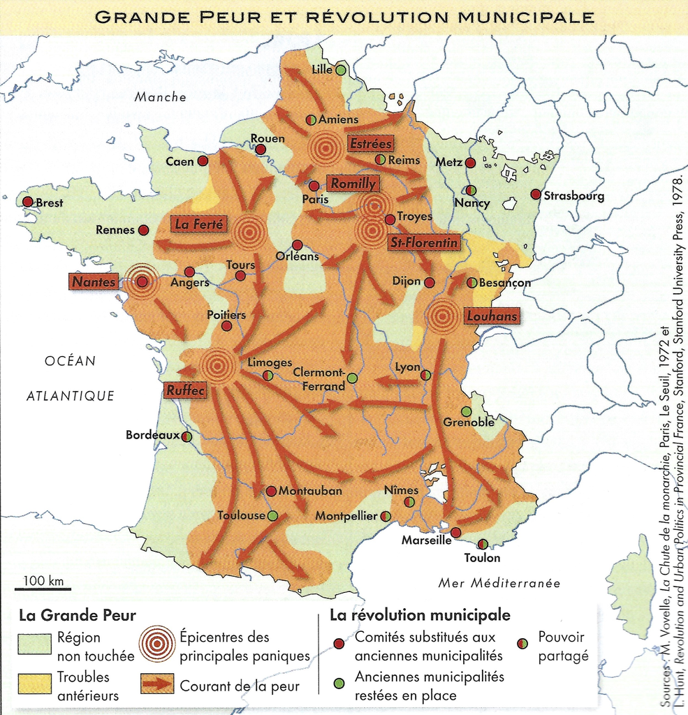

Les courants de la Grande peur

L’insurrection des campagnes est anti-fiscale, anti-ecclésiastique et surtout, anti-seigneuriale. Dirigée par des meneurs issus des catégories intermédiaires (prêtres, officiers d’armée, directeurs de manufactures…), elle s’attaque rarement aux seigneurs eux-mêmes – on compte moins de 5 meurtres pour tout le pays – mais l’on brûle les châteaux et surtout, les actes de propriété. En revanche, la défense organisée par les nobles et les bourgeois est souvent sanglante.  
La «Grande peur» fut d’abord la peur éprouvée par les campagnes, elle devint la peur des campagnes, éprouvée par les puissants. L’Assemblée cherche d’abord à éviter la guerre civile. On décide ne pas suivre la voie de la répression, de chercher l’apaisement. Le duc d’Aiguillon, plus grand propriétaire terrien du royaume, est approché en avance de la séance qui se prolonge dans la **nuit du 4 août**. L’abolition des privilèges, acte mis en scène par les nobles eux-mêmes dans la volonté de préserver le plus possible de leurs fortunes, signe la fin de l’ordre symbolique de l’Ancien régime. Cependant, les **droits réels**, ceux qui fondent la richesse des possédants, sont déclarés rachetables dès le lendemain. Les nobles renoncent aux symboles pour préserver la vraie richesse – il faudra attendre 1793 pour une abolition pure, simple et sans compensation.

> Monsieur, la séance du mardi au soir, 4 août, est la séance la plus mémorable qui se soit tenue jamais chez aucune nation. (…) M. le Vicomte de Noailles fit une motion, et demanda que les droits de banalité, rentes nobles foncières, droits de minage, exclusifs de chasse, de fuie, colombier, cens, redevances, dîmes, rachats, tous droits qui pèsent sur le peuple, et sont la source des déprédations des justices subalternes, des vexations des officiers, pussent être rachetés (…).

> Les ducs d’Aiguillon, du Châtelet, proposèrent que, dès le moment, la Noblesse et le Clergé prononçassent le sacrifice de leurs privilèges pécuniaires. Les circonstances malheureuses où se trouvent la Noblesse, l’insurrection générale élevée de toutes parts contre elle, (…) plus de cent cinquante châteaux incendiés ; les titres seigneuriaux recherchés avec une espèce de fureur, et brûlés ; l’impossibilité de s’opposer au torrent de la Révolution, les malheurs qu’entraînerait une résistance même inutile ; tout nous prescrivait la conduite que nous devions tenir ; il n’y eut qu’un mouvement général. Le Clergé, la Noblesse se levèrent et adoptèrent toutes les motions proposées.

> Lettre du marquis de Ferrières (député de la noblesse), 7 août 1789

Résumons: la Révolution ne pouvait commencer qu’à l’intérieur des institutions de l’État monarchique d’Ancien régime, elle ne pouvait continuer qu’en dehors d’elles. À la fin de l’été 1789, la Nation entière était entrée dans la révolution: en juin, les représentants, salués et applaudis par leurs *commettants* (électeurs), en juillet, le peuple des villes, en août, celui des campagnes. L’Ancien régime était fini – mais il restait à bâtir le nouveau.

## 3 Naissance et échec de la monarchie constitutionnelle

### 3.1 La constitution monarchique

Dès l’été 1789, le principe de doter le France d’une constitution est acté; la monarchie constitutionnelle, inspirée du modèle anglais, est l’horizon d’attente communément admis. Pour le moment, personne ou presque n’envisage la fin de la monarchie, difficile à imaginer malgré l’exemple américain.  
Les travaux de la Constituante durent jusqu’en 1791. S’il s’agit de construire un nouvel ordre juridique, façonné par les événements récents qui méritent déjà pleinement le nom de révolution, de nombreux acteurs des événements vivent désormais dans la peur du peuple, qu’il cherchent à pacifier et circonscrire.  
Ainsi, la monarchie constitutionnelle française sera **censitaire**: pour participer à une assemblée primaire, il faut être français, avoir 25 ans, être domicilié et payer une contribution directe égale à 3 jours de travail (1,5 à 3 livres); il faut 10 journées de travail (5 à 10 livres) pour être électeur, et pour être élu, en outre d’un marc d’argent (52 livres) de contribution, il faut être propriétaire foncier. Les plus pauvres, les étrangers et les femmes restent exclus des droits politiques.

> Les mères, les filles, les sœurs, représentantes de la nation, demandent d’être constituées en assemblée nationale. Considérant que l’oubli et le mépris des droits de la femme sont les seules causes des malheurs publics et de la corruption des gouvernements, ont résolu d’exposer dans une déclaration solennelle, les droits naturels, inaliénables et sacrés de la femme […]

> Art. VI La loi doit être l’expression de la volonté générale; toutes les citoyennes et tous les citoyens doivent concourir personnellement ou par leurs représentants à sa formation, elle doit être la même pour tous: toutes les citoyennes et tous les citoyens étant égaux à ses yeux, doivent être également admissibles à toutes dignités, places et emplois publics, selon leur capacités et sans autres distinctions que celles de leurs vertus et de leurs talents […]

> Olympe de Gouges, *Déclaration des droits de la femme*, septembre 1791

Le pouvoir législatif, détenu par l’Assemblée, est central; le roi devient alors le premier fonctionnaire du royaume.Il continue cependant à exercer un pouvoir exécutif, certes subordonné au législatif, et reste une figure symbolique importante. Dans les représentations partagées, l’attachement à la figure protectrice et paternelle du roi, éventuellement détourné de bonnes décisions par des mauvais conseillers, reste fort. Deux actes, instaurés par l’ordre constitutionnel de cette période, marquent durablement la suite des événements. D’une part, le territoire national est réorganisé. LA nouvelle carte introduit les départements et les districts, formés de cantons où se tiennent les assemblées primaires. La rupture avec la géographie traditionnelle choque les conservateurs; les Constituants eux-mêmes hésitent entre la volonté d’attacher les citoyens à la révolution grâce au pouvoir municipal important, et la crainte de voir émerger une opposition locale au pouvoir central. La crainte de l’«anarchie» l’emporte globalement, mais l’activité des districts permet une véritable expérience démocratique.

Tout aussi ambiguë est la création des Gardes nationales, dans le cadre municipal. Dominées par des citoyens aisés (il faut pouvoir payer son uniforme), les gardes sont créées comme des milices bourgeoises, destinées d’abord à réprimer les mouvements de contestation populaire, à commencer par la grande peur.

D’autre part, le 12 juillet 1790 est adoptée la **constitution civile du clergé**. Cette réorganisation de l’Église de France, qui s’inscrit dans la tradition du **gallicanisme** et qui s’inspire de la pensée *janséniste* correspond aux souhaits d’une bonne partie du bas-clergé, qui réclame de pouvoir gouverner l’Église démocratiquement.  
La carte ecclésiastique est simplifiée et calquée sur l’organisation administrative, un nombre de charges ainsi que des congrégations sont supprimés. Louis XVI approuve la Constitution civile du clergé le 24 août 1790, contre son gré et contre l’opposition du pape Pie VI. Ce dernier condamne le document dans deux brefs du printemps de l’année suivante, dans lesquels il demande aux religieux qui n’auraient pas encore juré cette constitution de ne pas le faire. Se développe ainsi une situation de schisme, où les prêtres **réfractaires**, qui refusent la constitution au nom de la fidélité au pape, s’opposent aux **jureurs** (autrement dit, **assermentés** ou **constitutionnels**, traités souvent d’«intrus»), qui l’avaient acceptée.

[figure not shown]

Schéma de l’organisation de la monarchie constitutionnelle

### 3.2 La Marche des femmes et la Déclaration des Droits de l’Homme

L’idée d’une déclaration des droits de l’homme et du citoyen était présente dès la phase de préparation des États généraux; la proposition concrète est discutée à partir du 9 juillet. Le principe d’en rédiger une et de la placer en tête de la future constitution est voté le jour du 4 août, c’est-à-dire juste avant la nuit de l’abolition des privilèges.  
Commence alors un travail long et minutieux. 27 projets sont préparés par des auteurs différents et servent de base de travail. Les articles sont ensuite discutés et votés progressivement.  
La Déclaration des droits de l’homme et du citoyen est le sommet de la Révolution juridique. Le texte est fait pour être un acte fondateur; sacralisé sous les auspices de l’Être suprême (pour ne pas dire Dieu), il est sacralisé.

[figure not shown]

*Déclaration des Droits de l’Homme et du Citoyen*, huile sur toile de Jean-Jacques François Le Barbier (l’Aîné), vers 1789

La Déclaration, texte constitutionnel toujours en vigueur puisqu’elle demeure annexée à la constitution actuelle, continue à être interprétée de nos jours.  
Son article premier consacre une liberté fondamentale, inaliénable, qui interdit de fait toute marchandisation (donc, l’esclavage) et toute soumission dans un rapport de domination. Elle conduit à l’égalité des droits et conduit à un régime de distinction fondé sur l’action pour le bien commun et non sur la naissance.  
Le droit de résister à l’oppression est affirmé comme l’un des droits fondamentaux. Il légitime la Révolution elle-même; l’institution démocratique est d’emblée liée à l’insurrection qui produit de nouvelles règles en réaction à l’oppression qui peut être immédiatement, intuitivement reconnue.  
En politique, le principe de la souveraineté nationale est affirmé; la loi est définie comme l’expression d’une volonté générale; la liberté individuelle comme protection contre les abus du pouvoir, liberté de la presse, l’égalité devant l’impôt, liberté de conscience et d’opinion, le contrôle des fonctionnaires sont énoncés.

> **Préambule**  
> Les représentants du peuple français, constitués en Assemblée nationale, considérant que l’ignorance, l’oubli ou le mépris des droits de l’homme sont les seules causes des malheurs publics et de la corruption des gouvernements, ont résolu d’exposer, dans une déclaration solennelle, les droits naturels, inaliénables et sacrés de l’homme, afin que cette déclaration, constamment présente à tous les membres du corps social, leur rappelle sans cesse leurs droits et leurs devoirs ; afin que les actes du pouvoir législatif et ceux du pouvoir exécutif, pouvant être à chaque instant comparés avec le but de toute institution politique, en soient plus respectés ; afin que les réclamations des citoyens, fondées désormais sur des principes simples et incontestables, tournent toujours au maintien de la Constitution et au bonheur de tous.

> En conséquence, l’Assemblée nationale reconnaît et déclare, en présence et sous les auspices de l’Être Suprême, les droits suivants de l’homme et du citoyen.

> **Article premier**: Les hommes naissent et demeurent libres et égaux en droits. Les distinctions sociales ne peuvent être fondées que sur l’utilité commune.

> **Article 2**: Le but de toute association politique est la conservation des droits naturels et imprescriptibles de l’homme. Ces droits sont la liberté, la propriété, la sûreté et la résistance à l’oppression.

> **Article 3**: Le principe de toute souveraineté réside essentiellement dans la Nation. Nul corps, nul individu ne peut exercer d’autorité qui n’en émane expressément.

> **Article 4**: La liberté consiste à pouvoir faire tout ce qui ne nuit pas à autrui : ainsi, l’exercice des droits naturels de chaque homme n’a de bornes que celles qui assurent aux autres membres de la société la jouissance de ces mêmes droits. Ces bornes ne peuvent être déterminées que par la loi.

> **Article 5**: La loi n’a le droit de défendre que les actions nuisibles à la société. Tout ce qui n’est pas défendu par la loi ne peut être empêché, et nul ne peut être contraint à faire ce qu’elle n’ordonne pas.

> **Article 6**: La loi est l’expression de la volonté générale. Tous les citoyens ont droit de concourir personnellement ou par leurs représentants à sa formation. Elle doit être la même pour tous, soit qu’elle protège, soit qu’elle punisse. Tous les citoyens, étant égaux à ses yeux, sont également admissibles à toutes dignités, places et emplois publics, selon leur capacité et sans autre distinction que celle de leurs vertus et de leurs talents.

> **Article 7**: Nul homme ne peut être accusé, arrêté ou détenu que dans les cas déterminés par la loi et selon les formes qu’elle a prescrites. Ceux qui sollicitent, expédient, exécutent ou font exécuter des ordres arbitraires doivent être punis ; mais tout citoyen appelé ou saisi en vertu de la loi doit obéir à l’instant ; il se rend coupable par la résistance.

> **Article 8**: La loi ne doit établir que des peines strictement et évidemment nécessaires, et nul ne peut être puni qu’en vertu d’une loi établie et promulguée antérieurement au délit, et légalement appliquée.

> **Article 9**: Tout homme étant présumé innocent jusqu’à ce qu’il ait été déclaré coupable, s’il est jugé indispensable de l’arrêter, toute rigueur qui ne serait pas nécessaire pour s’assurer de sa personne doit être sévèrement réprimée par la loi.

> **Article 10**: Nul ne doit être inquiété pour ses opinions, même religieuses, pourvu que leur manifestation ne trouble pas l’ordre public établi par la loi.

> **Article 11**: La libre communication des pensées et des opinions est un des droits les plus précieux de l’homme ; tout citoyen peut donc parler, écrire, imprimer librement, sauf à répondre de l’abus de cette liberté dans les cas déterminés par la loi.

> **Article 12**: La garantie des droits de l’homme et du citoyen nécessite une force publique ; cette force est donc instituée pour l’avantage de tous, et non pour l’utilité particulière de ceux à qui elle est confiée.

> **Article 13**: Pour l’entretien de la force publique, et pour les dépenses d’administration, une contribution commune est indispensable ; elle doit être également répartie entre les citoyens, en raison de leurs facultés.

> **Article 14**: Les citoyens ont le droit de constater, par eux-mêmes ou par leurs représentants, la nécessité de la contribution publique, de la consentir librement, d’en suivre l’emploi, et d’en déterminer la quotité, l’assiette, le recouvrement et la durée.

> **Article 15**: La société a le droit de demander compte à tout agent public de son administration.

> **Article 16**: Toute société dans laquelle la garantie des droits n’est pas assurée ni la séparation des pouvoirs déterminée, n’a point de Constitution.

> **Article 17**: La propriété étant un droit inviolable et sacré, nul ne peut en être privé, si ce n’est lorsque la nécessité publique, légalement constatée, l’exige évidemment, et sous la condition d’une juste et préalable indemnité.

### 3.3 «Monsieur veto»: vers l’échec

La Déclaration est votée le 26 août, mais n’est pas encore ratifiée par le roi. Pendant ce temps, l’Assemblée débat sur la question du droit de veto du roi: un veto absolu, veto suspensif, ou pas de veto du tout. Confier au roi le droit de veto signifie un risque de paralysie; les conservateurs anti-révolutionnaires, qui souhaitent une monarchie à l’anglaise, sont partisans d’un veto absolu. La solution adoptée est celle d’un veto suspensif.  
Le roi, hostile au processus révolutionnaire, reste à Versailles, où il se sent plus en sécurité, sous la protection du régiment de Flandre qui porte la cocarde noire de la reine plutôt que la cocarde tricolore nationale. À Paris, les provisions manquent, les rumeurs sur les accapareurs et les craintes de la répression militaire se multiplient. Mais les assemblées de districts, sortes de parlements locaux, assurent une articulation efficace entre la population et l’Assemblée nationale. Une riposte insurrectionnelle devient inévitable.  
Le 5 octobre, les femmes de la Halle se réunissent à l’Hôtel de ville, s’emparent de 1700 fusils et 4 canons, et prennent la tête d’un cortège qui se dirige vers Versailles. Elles sont rejointes par les hommes des faubourgs, puis les soldats; enfin, La Fayette, qui avait cherché à empêcher toute insurrection, est forcé d’accompagner le mouvement. Le couple royal est forcé de ratifier les décrets du 4 août et la Déclaration des droits de l’homme (DDHC) et de revenir à Paris.

[figure not shown]

La marche des femmes sur Versailles, 5-6 octobre 1789

## Conclusion

La révolution juridique et institutionnelle aboutit à satisfaire ce qui apparaissait comme le fonds raisonnable des demandes de la société de l’Ancien régime finissant: une monarchie constitutionnelle à l’anglaise, modérée, garantissant les libertés individuelles et préservant les grandes fortunes. Or, cela ne satisfait pas.  
La monarchie constitutionnelle était le choix de la stabilité. Elle a été construite dans la volonté d’arrêter et contenir la révolution. Mais le mouvement une fois déclenché, ne pouvait pas s’arrêter là. En réalité, la monarchie constitutionnelle, dans laquelle le roi, pièce maîtresse du système, fait tout pour résister à cette nouvelle réalité et revenir au passé, était mort-née.  
Une fois la nation entière entrée dans la révolution, une fois qu’elle s’est manifestée à elle même et que les dirigeants eux-mêmes ont été obligés de la reconnaître (pour parler comme Pascal…), la révolution devait se poursuivre.